# Annual Greenhouse Gas (GHG) Air Emissions Accounts

### **Research Question 3: How well does the model predict annual greenhouse gas (GHG) emissions for the year 2022 based on historical data from the year 2013?**

```python
from sklearn.model_selection import train_test_split
from sklearn.linear_model import LinearRegression
from sklearn.metrics import mean_squared_error, r2_score

# Prepare data
X = df[['F2013']]
y = df['F2022']

# Split the data into training and testing sets
X_train, X_test, y_train, y_test = train_test_split(X, y, test_size=0.2, random_state=42)

# Model selection
model = LinearRegression()

# Training
model.fit(X_train, y_train)

# Evaluation
predictions = model.predict(X_test)
mse = mean_squared_error(y_test, predictions)
r2 = r2_score(y_test, predictions)

print(f'Mean Squared Error: {mse}')
print(f'R-squared: {r2}')
```

```
Mean Squared Error: 75779.141084421
R-squared: 0.9924120559327425
```

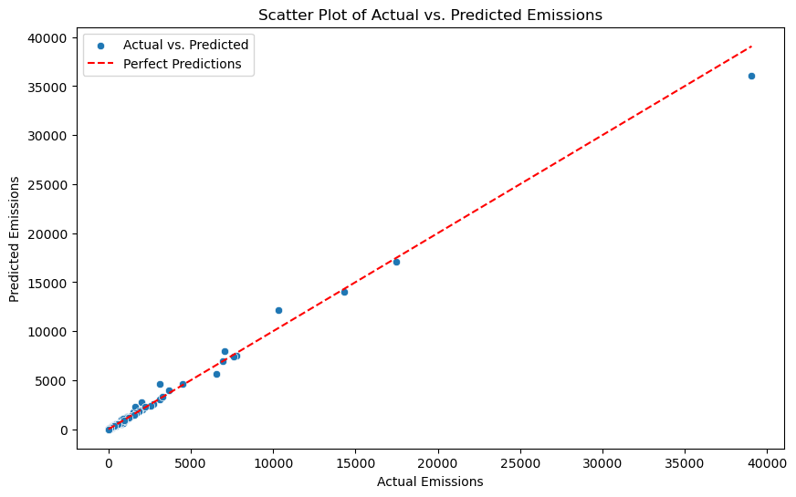

```python
import numpy as np
import matplotlib.pyplot as plt
import seaborn as sns
from sklearn.metrics import mean_squared_error, r2_score
# Scatter plot
plt.figure(figsize=(10, 6))
sns.scatterplot(x=y_test, y=predictions, label='Actual vs. Predicted')

# Add a line for perfect predictions
plt.plot([y_test.min(), y_test.max()], [y_test.min(), y_test.max()], '--', color='red', label='Perfect Predictions')

plt.title('Scatter Plot of Actual vs. Predicted Emissions')
plt.xlabel('Actual Emissions')
plt.ylabel('Predicted Emissions')
plt.legend()
plt.show()
```

A linear regression model was used to predict the annual GHG emissions in 2022 based on the historical data of 2013. The mean squared error (MSE) of the model was as low as 75779.14 and the R-squared value was as high as 0.9924, indicating that the model has a high degree of accuracy. The scatterplot visualises the relationship between actual and predicted emissions, showing a strong link along the diagonal. The red dashed line represents a perfect prediction and the proximity of the points to the line further emphasises the accuracy of the model. Overall, the high R-squared values indicate that the model effectively captures changes in GHG emissions based on historical data, demonstrating the reliability of its projections for 2022 emissions.